# TU060 - Math 9102 – PSI - Assignment

##### 3.4.1.2.3 Homoscedasticity of Residuals

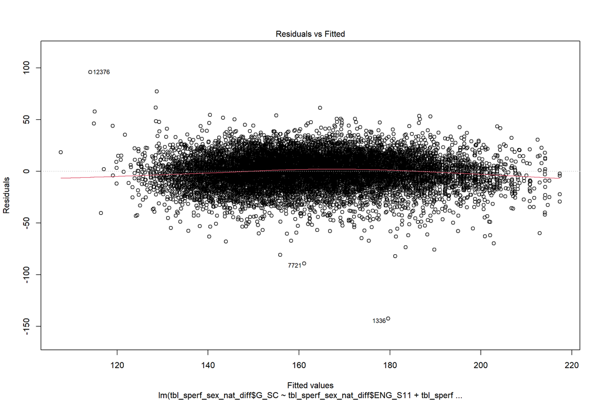

```r
############
# PART: Model 3 Check for homoscedasticity outliers
############
# --------------- residuals vs fitted values ---------- #
plot(reg_model_3, 1)
```

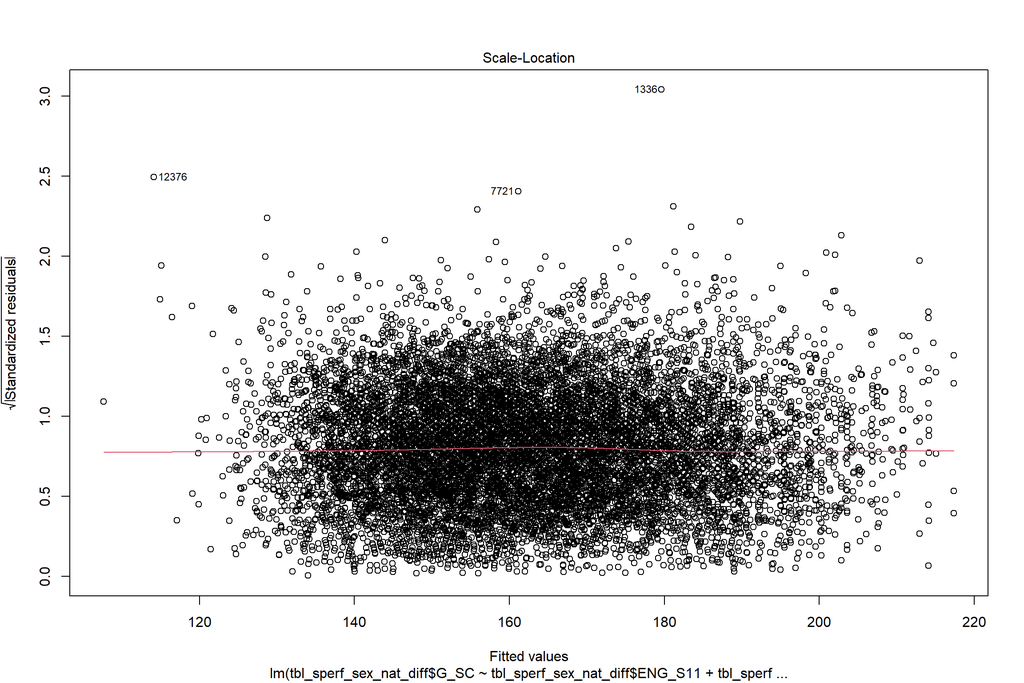

```r
# --------------- studentized residuals --------------- #
plot(reg_model_3, 3)
```

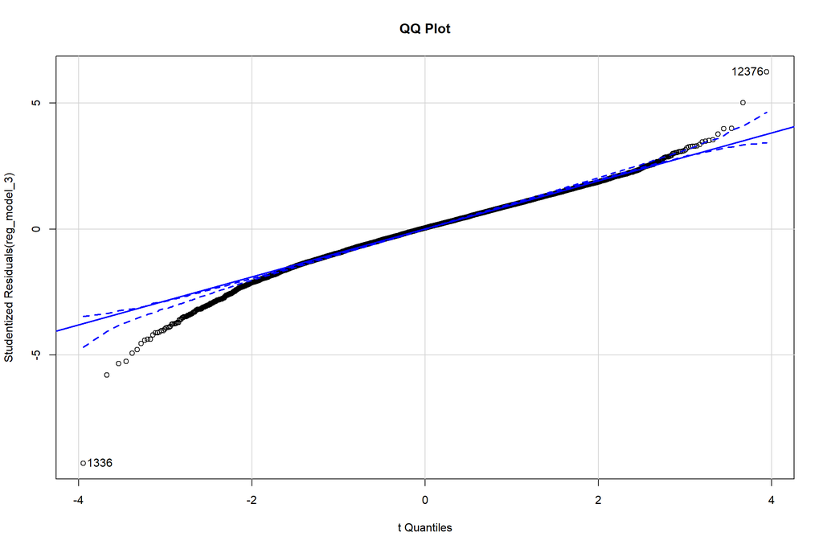

```
## [1]  1336 12376
```

```r
# --------------- Q-Q plot studentized residuals --------------- #
car::qqPlot(reg_model_3, main = "QQ Plot") #qq plot for studentized resid
```

##### 3.4.1.2.4 Collinearity of predictors

No correlation coefficient above 0.8 was found indicating no strong correlation is present. We did not generate a variance inflation factor (VIF) for each predictor as the inclusion of interaction terms and a switching term meant that all variables would have at least one term in the model that resulted in a high VIF statistic.

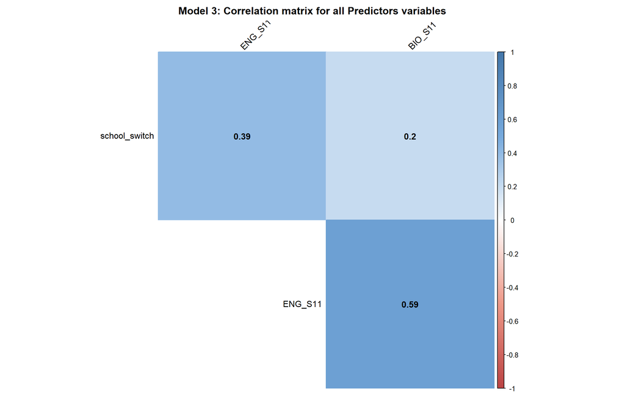

```r
### Correlation matrix for all
correlation_matrix <- tbl_sperf_sex_nat_diff %>%
        select(ENG_S11,BIO_S11,school_switch) %>%
        as.matrix() %>%
        Hmisc::rcorr()

col <- colorRampPalette(c("#BB4444", "#EE9988", "#FFFFFF", "#77AADD", "#4477AA"))
title <- "Model 3: Correlation matrix for all Predictors variables"
gs <- corrplot::corrplot(correlation_matrix$r, method = "color", col = col(200), type = "upper", order = "hclust", addCoef.col = "black",              # Add coefficient of correlation
               tl.col                       = "black", tl.srt = 45,                                                                          #Text label color and rotation
               # Combine with significance
               p.mat                        = correlation_matrix$p, sig.level = 0.01, insig = "blank",
               # hide correlation coefficient on the principal diagonal
               diag                         = FALSE, title = title, mar = c(0, 0, 2, 0) ) # http://stackoverflow.com/a/14754408/54964)
```

### 3.4.2 Reporting on Model 3

The following predictive model was generated:

$$\begin{equation}
G\_SC\ (Predicted) = 0.687*ENG\_S11 + 0.947*BIO\_S11 + (10.603 - 0.139*BIO\_S11- 0.025*ENG\_S11)*PRIVATE_SCHOOL + 59.890
\tag{3.3}
\end{equation}$$

The relationship between high school biology score (BIO_S11), high school engineering score (ENG_S11), school nature (SCHOOL_NATURE) and university final performance (G_SC) was modeled using a multiple linear model. The model was found to be statistically significant difference at the p < .001 level (F(5, 12405)= 3101, p<0.01). The model explains 56% of the variance in the outcome variable $Adjusted R^2 = .0.555$.

Examination of the histogram, normal P-P plot of standardised residuals and the scatterplot of the dependent variable, final university score, and standardised residuals showed that some outliers existed. However, examination of the standardised residuals showed that none could be considered to have undue influence (95% within limits of +/1 1.96 and none with Cook’s distance > 1).

The scatterplot of standardised residuals showed that the data met the assumptions of homogeneity of variance and linearity. The data also meets the assumption of non-zero variances of the predictor. Examination for multicollinearity showed a small correlation between school nature and biology or engineering scores at high school.

Again, causality can be assumed since students attend highschool before university. Similarly, independence is assured since each student is unique and each evaluation independently assessed.

## 3.5 Summary Comparison

As part of the statistical analysis we generated three predictive models.

```
##
## =============================================================================================================
##                                                         Dependent variable:
##                        --------------------------------------------------------------------------------------
##                                                                 G_SC
##                                    (1)                          (2)                          (3)
## -------------------------------------------------------------------------------------------------------------
## ENG_S11                          0.595***                     0.665***                     0.687***
##                                  (0.012)                      (0.012)                      (0.022)
##
## MAT_S11                          0.386***
##                                  (0.018)
##
## BIO_S11                          0.615***                     0.875***                     0.947***
##                                  (0.020)                      (0.015)                      (0.022)
##
## int_bio_school_private                                                                    -0.139***
##                                                                                            (0.031)
##
## int_eng_school_private                                                                      -0.025
##                                                                                            (0.027)
##
## school_switch                                                                             10.603***
##                                                                                            (1.730)
##
## Constant                        61.774***                    65.628***                    59.890***
##                                  (0.828)                      (0.822)                      (1.283)
##
## -------------------------------------------------------------------------------------------------------------
## Observations                      12,411                       12,411                       12,411
## R2                                0.569                        0.554                        0.556
## Adjusted R2                       0.569                        0.554                        0.555
## Residual Std. Error        15.169 (df = 12407)          15.434 (df = 12408)          15.412 (df = 12405)
## F Statistic            5,467.291*** (df = 3; 12407) 7,710.735*** (df = 2; 12408) 3,100.835*** (df = 5; 12405)
## =============================================================================================================
## Note:                                                                             *p<0.1; **p<0.05; ***p<0.01
```

|  | #Df | LogLik | Df | Chisq | Pr(>Chisq) |
| --- | --- | --- | --- | --- | --- |
| 1 | 5 | -51357.46 | NA | NA | NA |
| 2 | 4 | -51572.59 | -1 | 430.2704 | 1.419208e-95 |
| 3 | 7 | -51553.35 | 3 | 38.4960 | 2.219312e-08 |

|  | Res.Df | RSS | Df | Sum of Sq | F | Pr(>F) |
| --- | --- | --- | --- | --- | --- | --- |
| 1 | 12408 | 2955709 | NA | NA | NA | NA |
| 2 | 12405 | 2946555 | 3 | 9153.711 | 12.84571 | 2.237852e-08 |

|  | Res.Df | RSS | Df | Sum of Sq | F | Pr(>F) |
| --- | --- | --- | --- | --- | --- | --- |
| 1 | 12408 | 2955709 | NA | NA | NA | NA |
| 2 | 12407 | 2854995 | 1 | 100714 | 437.6746 | 1.534582e-95 |

### 3.5.2 Assumptions

With the exception of Model 1 (3.1), which did need not meet the criteria regarding multi Collinearity, all tested assumptions were met for all models.

- The outcome variable was a continuous variable.
- All predictor variables were shown to be either continuous normally distributed or dichotomous.
- All variables had non-zero Variance:
- A linear relationship was shown.
- All values of the outcome should come from a different person.
- Residuals where shown to be normally distributed within acceptable limits with a constant variance
- No significant outliers, influence or leverage points had to be removed.
- We can assert causality as conceptually all predictor variable values are determined prior to the outcome variable.

# 4 Discussion/Conclusion

e find that there is reason to accept our first hypothesis that Students who perform well overall in highschool will perform well in engineering at university. Furthermore there is also justification to accept the second hypothesis that Students who attend private high schools will perform better overall in engineering at university. The predictive model selection can account for 56% of the variation in final student performance which is a very useful model in the education domain.

It was surprising to find that biology and maths had multi Collinearity, as an additional step it would be interesting to perform factoring to see if a newly constructed feature could be generated to represent this relationship.

# References:

- Delahoz-Dominguez, Enrique, Rohemi Zuluaga, and Tomas Fontalvo-Herrera. “Dataset of academic performance evolution for engineering students.” *Data in Brief (2020)*: 105537.
- Cortez and A. Silva. “Using Data Mining to Predict Secondary School Student Performance.” In A. Brito and J. Teixeira Eds., Proceedings of 5th FUture BUsiness TEChnology Conference (FUBUTEC 2008) pp. 5-12, Porto, Portugal, April, 2008, EUROSIS, ISBN 978-9077381-39-7. (https://repositorium.sdum.uminho.pt/bitstream/1822/8024/1/student.pdf)
- Cohen, J. (1988). Set Correlation and Contingency Tables. Applied Psychological Measurement, 12(4), 425–434. https://doi.org/10.1177/014662168801200410
- George, Darren & Mallery, Paul. (2003). SPSS for Windows Step-by-Step: A Simple Guide and Reference, 14.0 update (7th Edition). http://lst-iiep.iiep-unesco.org/cgi-bin/wwwi32.exe/[in=epidoc1.in]/?t2000=026564/(100).
- Tabachnick, B. G., Fidell, L. S., & Ullman, J. B. (2007). Using multivariate statistics (Vol. 5, pp. 481-498). Boston, MA: Pearson.
- Cook, R. D., & Weisberg, S. (1982). Residuals and influence in regression. New York: Chapman and Hall.
- Myers, R. H., & Myers, R. H. (1990). Classical and modern regression with applications (Vol. 2). Belmont, CA: Duxbury press.
- Tarling, R. (2008). Statistical modelling for social researchers: Principles and practice. Routledge.
- Field, Andy; Miles, Jeremy; Field, Zoe. Discovering Statistics Using R (p. iv). SAGE Publications. (2008)